# AZENTA NGS PacBio Data Report

- Project
- Workflow
- CCS Analysis
- Deliverables

# AZENTA NGS PacBio Data Report

## 1. Project

| Customer | Paul Metz |
| --- | --- |
| Email | paul.metz@msdtc.ox.ac.uk |
| Sample Type | Frozen Cells |
| Quote Number | 40-561263025 |
| Configuration | PacBio Sequel II |

## 2. Workflow

### 2.1 PacBio sequel sequencing workflow

Purified DNA was fragmented and damage/end repaired. Adapters (containing unique barcode sequences if multiple samples were multiplexed and analyzed on one SMRT cell) were ligated to the DNA fragments. Prepared libraries were purified (samples were pooled together before purification if multiplexed). Sequencing primers were annealed to form polymerase-primer complexes and the resulting complexes were sequenced. Figure 2.1 outlines the PacBio library preparation and sequencing workflow.

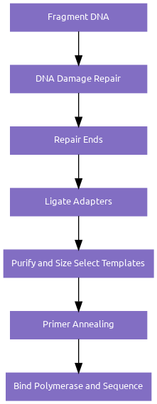

Figure 2.1 Pacbio library preparation and sequencing workflow

## 3. CCS Analysis

### 3.1 CCS read Statistics

| Sample ID | CCS Reads | Number of CCS Bases | CCS Read Length (mean) | CCS Read Score (mean) | Number of Passes (mean) |
| --- | --- | --- | --- | --- | --- |
| 26T | 1816111 | 27115055034 | 14930 | 0.999 | 12 |
| 8814 | 2367375 | 35349390275 | 14931 | 0.999 | 13 |

### 3.2 CCS Read Length

[interactive chart not shown]

Figure 3.2 CCS data read length distribution

### 3.3 CCS Read Score

[interactive chart not shown]

Figure 3.3 CCS data read score distribution

### 3.4 Number of Passes

[interactive chart not shown]

Figure 3.4 CCS data pass number distribution

[interactive chart not shown]

Figure 3.5 CCS data pass number vs. read score correlation

## 4. Deliverables

- Data Analysis Report.
- Raw reads.bam output and supporting files.
- Demultiplexed output and supporting files (if applicable).
- Fastq files with CCS reads for each sample.
- Azenta Life Sciences
- Next Generation Sequencing
- Email: ngs@azenta.com
- Phone: 908-222-0711 ext 1